# Weed Classification in Drone Images with Convolutional Networks

Let's start by installing the libraries we will be using:

```python
!pip install rasterio
```

```
Downloading rasterio-1.4.3-cp310-cp310-manylinux_2_17_x86_64.manylinux2014_x86_64.whl (22.2 MB)
   ━━━━━━━━━━━━━━━━━━━━━━━━━━━━━━━━━━━━━━━━ 22.2/22.2 MB 31.0 MB/s eta 0:00:00
Downloading cligj-0.7.2-py3-none-any.whl (7.1 kB)
Downloading affine-2.4.0-py3-none-any.whl (15 kB)
Downloading click_plugins-1.1.1-py2.py3-none-any.whl (7.5 kB)
```

We connect to Google Drive:

```python
from google.colab import drive
drive.mount('/content/drive')
```

Now, let's install the libraries:

```python
import os
import cv2
import matplotlib.pyplot as plt
import numpy as np
import rasterio
from rasterio.windows import Window
import pandas as pd
import geopandas as gpd
from pylab import rcParams
import matplotlib
rcParams['figure.figsize'] = 18, 16
from sklearn.model_selection import train_test_split
from rasterio.plot import show
from shapely.geometry import box
from rasterio.plot import show
```

The image and shapefiles to be used are stored in Drive. A point file was collected for each class we have.

```python
path_img = '/content/drive/MyDrive/Datasets/classificacao_cana_daninhas/AOI_img_rep.tif'
path_classe1 = '/content/drive/MyDrive/Datasets/classificacao_cana_daninhas/Classe_1.shp'
path_classe2 = '/content/drive/MyDrive/Datasets/classificacao_cana_daninhas/Classe_2.shp'
path_classe3 = '/content/drive/MyDrive/Datasets/classificacao_cana_daninhas/Classe_3.shp'
```

Let's use geopandas to open the Shapefiles and plot them along with the image:

```python
gdf1 = gpd.read_file(path_classe1)
gdf2 = gpd.read_file(path_classe2)
gdf3 = gpd.read_file(path_classe3)
```

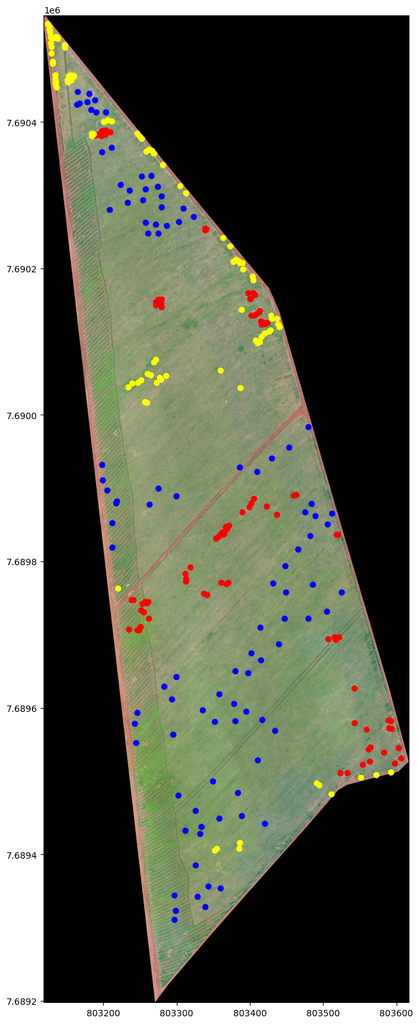

```python
fig, ax = plt.subplots(figsize=(20, 20))
with rasterio.open(path_img) as src:
    gdf1 = gdf1.to_crs(src.crs.to_dict())
    gdf2 = gdf2.to_crs(src.crs.to_dict())
    gdf3 = gdf3.to_crs(src.crs.to_dict())
    show(src,ax=ax)
gdf1.plot(ax=ax, color='red')
gdf2.plot(ax=ax, color='yellow')
gdf3.plot(ax=ax, color='blue')
```

Then we can start extracting information with the image and shapefiles:

```python
src = rasterio.open(path_img)
im = src.read()
```

```python
im = im.transpose([1,2,0])
```

```python
im.shape
```

```
(23835, 8821, 4)
```

```python
im = im.astype('uint8')
```

We create a field called 'id' in all geodataframes to aggregate the sample class, then join them into a single geodataframe:

```python
gdf1['id'] = 0
gdf2['id'] = 1
gdf3['id'] = 2
```

```python
gdf = pd.concat([gdf1,gdf2,gdf3], axis=0)
```

```python
img_list = []
label_list = []
for i,pt in gdf.iterrows():
  x = pt['geometry'].xy[0][0]
  y = pt['geometry'].xy[1][0]
  label = pt['id']
  row, col = src.index(x,y)
  img_path = im[row-64:row+64,col-64:col+64,0:3]


  img_list.append(img_path)
  label_list.append(label)
```

We create a variable X to receive the list of images and convert it into a numpy array:

```python
X = np.array(img_list)
Y = np.array(label_list)
```

```python
X.shape
```

```
(300, 128, 128, 3)
```

```python
Y.shape
```

```
(300,)
```

```python
del im, src, img_list, label_list
```

Let's draw an example:

```python
dict_name = {0:'Daninha_tipo_1', 1: 'Daninha_tipo_2', 2:'Normal'}
```

```
(-0.5, 127.5, 127.5, -0.5)
```

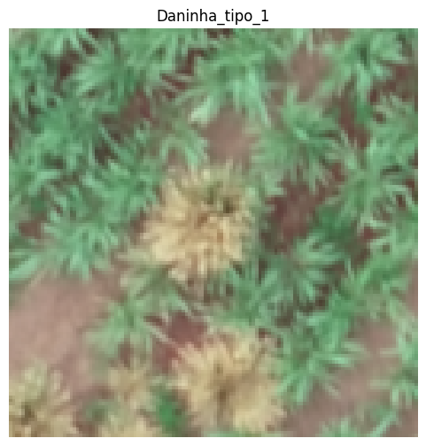

```python
i = 20
plt.figure(figsize=[6,6])
plt.title(dict_name[Y[i]])
plt.imshow(X[i])
plt.axis('off')
```

We normalize the images to the range from 0 to 1:

```python
X = X/255
```

Since we are working with categorical data, we need to encode categorical values into binary values so that they are compatible with the expected results of a neural network:

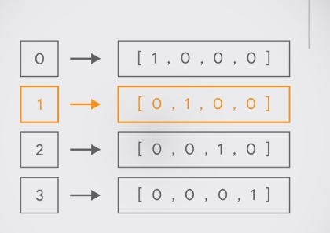

```python
from sklearn.preprocessing import OneHotEncoder
```

```python
Y = Y[:,np.newaxis]
```

```python
enc = OneHotEncoder()

enc.fit(Y)

Y = enc.transform(Y).toarray()
```

First, we will separate the data into training data and test data:

```python
x_train, x_test, y_train, y_test = train_test_split(X, Y, test_size = 0.3, random_state = 42)
```

```python
n_classes = 3
```

Now let’s import some Keras functions and create our convolutional network:

```python
from keras.models import Model, Sequential
from keras.layers import Input, Conv2D, MaxPooling2D, Flatten, Dense, BatchNormalization, Dropout, Activation
#from tensorflow.keras.optimizers.legacy import Adam
from keras.optimizers import Adam
from keras.activations import relu
from keras.losses import binary_crossentropy
from keras import backend as K
import tensorflow as tf
from keras.models import load_model
from tensorflow.keras.preprocessing.image import ImageDataGenerator
```

```python
Model = Sequential()
Model.add(Conv2D(32,(3,3), kernel_initializer="he_normal", padding='same', input_shape=(x_train.shape[1:])))
Model.add(Activation('relu'))
Model.add(MaxPooling2D(pool_size=(2,2),strides=2))
Model.add(Conv2D(64,(3,3), kernel_initializer="he_normal", padding='same'))
Model.add(Activation('relu'))
Model.add(MaxPooling2D(pool_size=(2,2),strides=2))
Model.add(Conv2D(128,(3,3), kernel_initializer="he_normal", padding='same'))
Model.add(Activation('relu'))
Model.add(MaxPooling2D(pool_size=(2,2),strides=2))
Model.add(Conv2D(256,(3,3), kernel_initializer="he_normal", padding='same'))
Model.add(Activation('relu'))
Model.add(MaxPooling2D(pool_size=(2,2),strides=2))
Model.add(Flatten())
Model.add(Dropout(0.5))
Model.add(Dense(512))
Model.add(Activation('relu'))
Model.add(Dense(n_classes))
Model.add(Activation('softmax'))
Model.compile(loss='categorical_crossentropy', optimizer=Adam(learning_rate=0.00001), metrics=['accuracy'])
Model.summary()
```

```
Model: "sequential"
```

```
┏━━━━━━━━━━━━━━━━━━━━━━━━━━━━━━━━━━━━━━┳━━━━━━━━━━━━━━━━━━━━━━━━━━━━━┳━━━━━━━━━━━━━━━━━┓
┃ Layer (type)                         ┃ Output Shape                ┃         Param # ┃
┡━━━━━━━━━━━━━━━━━━━━━━━━━━━━━━━━━━━━━━╇━━━━━━━━━━━━━━━━━━━━━━━━━━━━━╇━━━━━━━━━━━━━━━━━┩
│ conv2d (Conv2D)                      │ (None, 128, 128, 32)        │             896 │
├──────────────────────────────────────┼─────────────────────────────┼─────────────────┤
│ activation (Activation)              │ (None, 128, 128, 32)        │               0 │
├──────────────────────────────────────┼─────────────────────────────┼─────────────────┤
│ max_pooling2d (MaxPooling2D)         │ (None, 64, 64, 32)          │               0 │
├──────────────────────────────────────┼─────────────────────────────┼─────────────────┤
│ conv2d_1 (Conv2D)                    │ (None, 64, 64, 64)          │          18,496 │
├──────────────────────────────────────┼─────────────────────────────┼─────────────────┤
│ activation_1 (Activation)            │ (None, 64, 64, 64)          │               0 │
├──────────────────────────────────────┼─────────────────────────────┼─────────────────┤
│ max_pooling2d_1 (MaxPooling2D)       │ (None, 32, 32, 64)          │               0 │
├──────────────────────────────────────┼─────────────────────────────┼─────────────────┤
│ conv2d_2 (Conv2D)                    │ (None, 32, 32, 128)         │          73,856 │
├──────────────────────────────────────┼─────────────────────────────┼─────────────────┤
│ activation_2 (Activation)            │ (None, 32, 32, 128)         │               0 │
├──────────────────────────────────────┼─────────────────────────────┼─────────────────┤
│ max_pooling2d_2 (MaxPooling2D)       │ (None, 16, 16, 128)         │               0 │
├──────────────────────────────────────┼─────────────────────────────┼─────────────────┤
│ conv2d_3 (Conv2D)                    │ (None, 16, 16, 256)         │         295,168 │
├──────────────────────────────────────┼─────────────────────────────┼─────────────────┤
│ activation_3 (Activation)            │ (None, 16, 16, 256)         │               0 │
├──────────────────────────────────────┼─────────────────────────────┼─────────────────┤
│ max_pooling2d_3 (MaxPooling2D)       │ (None, 8, 8, 256)           │               0 │
├──────────────────────────────────────┼─────────────────────────────┼─────────────────┤
│ flatten (Flatten)                    │ (None, 16384)               │               0 │
├──────────────────────────────────────┼─────────────────────────────┼─────────────────┤
│ dropout (Dropout)                    │ (None, 16384)               │               0 │
├──────────────────────────────────────┼─────────────────────────────┼─────────────────┤
│ dense (Dense)                        │ (None, 512)                 │       8,389,120 │
├──────────────────────────────────────┼─────────────────────────────┼─────────────────┤
│ activation_4 (Activation)            │ (None, 512)                 │               0 │
├──────────────────────────────────────┼─────────────────────────────┼─────────────────┤
│ dense_1 (Dense)                      │ (None, 3)                   │           1,539 │
├──────────────────────────────────────┼─────────────────────────────┼─────────────────┤
│ activation_5 (Activation)            │ (None, 3)                   │               0 │
└──────────────────────────────────────┴─────────────────────────────┴─────────────────┘
```

```
 Total params: 8,779,075 (33.49 MB)
```

```
 Trainable params: 8,779,075 (33.49 MB)
```

```
 Non-trainable params: 0 (0.00 B)
```

Then we can train the network:

```python
history = Model.fit(x = x_train, y= y_train, batch_size=64, epochs=200, verbose=1, shuffle=True, validation_split=0.2)
```

```
3/3 ━━━━━━━━━━━━━━━━━━━━ 13s 3s/step - accuracy: 0.3248 - loss: 1.3592 - val_accuracy: 0.3095 - val_loss: 1.2953
3/3 ━━━━━━━━━━━━━━━━━━━━ 0s 47ms/step - accuracy: 0.3150 - loss: 1.3740 - val_accuracy: 0.3095 - val_loss: 1.1284
3/3 ━━━━━━━━━━━━━━━━━━━━ 0s 47ms/step - accuracy: 0.3731 - loss: 1.2137 - val_accuracy: 0.3095 - val_loss: 1.0831
3/3 ━━━━━━━━━━━━━━━━━━━━ 0s 47ms/step - accuracy: 0.4351 - loss: 1.2063 - val_accuracy: 0.3095 - val_loss: 1.0657
3/3 ━━━━━━━━━━━━━━━━━━━━ 0s 46ms/step - accuracy: 0.2925 - loss: 1.2964 - val_accuracy: 0.3095 - val_loss: 1.1471
3/3 ━━━━━━━━━━━━━━━━━━━━ 0s 47ms/step - accuracy: 0.3415 - loss: 1.1785 - val_accuracy: 0.3095 - val_loss: 1.1583
3/3 ━━━━━━━━━━━━━━━━━━━━ 0s 47ms/step - accuracy: 0.3850 - loss: 1.1939 - val_accuracy: 0.3095 - val_loss: 1.0602
3/3 ━━━━━━━━━━━━━━━━━━━━ 0s 47ms/step - accuracy: 0.4182 - loss: 1.1891 - val_accuracy: 0.3095 - val_loss: 1.0094
3/3 ━━━━━━━━━━━━━━━━━━━━ 0s 45ms/step - accuracy: 0.3642 - loss: 1.1492 - val_accuracy: 0.3095 - val_loss: 1.0363
3/3 ━━━━━━━━━━━━━━━━━━━━ 0s 46ms/step - accuracy: 0.4359 - loss: 1.1069 - val_accuracy: 0.3095 - val_loss: 1.0705
3/3 ━━━━━━━━━━━━━━━━━━━━ 0s 45ms/step - accuracy: 0.4399 - loss: 1.0786 - val_accuracy: 0.3095 - val_loss: 1.0286
3/3 ━━━━━━━━━━━━━━━━━━━━ 0s 47ms/step - accuracy: 0.4095 - loss: 1.1609 - val_accuracy: 0.3810 - val_loss: 0.9967
3/3 ━━━━━━━━━━━━━━━━━━━━ 0s 45ms/step - accuracy: 0.4853 - loss: 1.0309 - val_accuracy: 0.3810 - val_loss: 0.9848
3/3 ━━━━━━━━━━━━━━━━━━━━ 0s 47ms/step - accuracy: 0.4589 - loss: 1.1120 - val_accuracy: 0.3810 - val_loss: 0.9961
3/3 ━━━━━━━━━━━━━━━━━━━━ 0s 48ms/step - accuracy: 0.5029 - loss: 1.0291 - val_accuracy: 0.3333 - val_loss: 0.9943
3/3 ━━━━━━━━━━━━━━━━━━━━ 0s 46ms/step - accuracy: 0.5907 - loss: 0.9697 - val_accuracy: 0.3333 - val_loss: 0.9820
3/3 ━━━━━━━━━━━━━━━━━━━━ 0s 45ms/step - accuracy: 0.5196 - loss: 0.9942 - val_accuracy: 0.4524 - val_loss: 0.9582
3/3 ━━━━━━━━━━━━━━━━━━━━ 0s 45ms/step - accuracy: 0.5472 - loss: 0.9743 - val_accuracy: 0.4048 - val_loss: 0.9655
3/3 ━━━━━━━━━━━━━━━━━━━━ 0s 46ms/step - accuracy: 0.4665 - loss: 1.0591 - val_accuracy: 0.4048 - val_loss: 0.9692
3/3 ━━━━━━━━━━━━━━━━━━━━ 0s 46ms/step - accuracy: 0.5383 - loss: 0.9812 - val_accuracy: 0.4524 - val_loss: 0.9354
3/3 ━━━━━━━━━━━━━━━━━━━━ 0s 46ms/step - accuracy: 0.5755 - loss: 0.9465 - val_accuracy: 0.4762 - val_loss: 0.9225
3/3 ━━━━━━━━━━━━━━━━━━━━ 0s 46ms/step - accuracy: 0.6240 - loss: 0.8641 - val_accuracy: 0.5000 - val_loss: 0.8997
3/3 ━━━━━━━━━━━━━━━━━━━━ 0s 46ms/step - accuracy: 0.5767 - loss: 0.8785 - val_accuracy: 0.5476 - val_loss: 0.8799
3/3 ━━━━━━━━━━━━━━━━━━━━ 0s 49ms/step - accuracy: 0.5827 - loss: 0.8510 - val_accuracy: 0.5238 - val_loss: 0.8884
3/3 ━━━━━━━━━━━━━━━━━━━━ 0s 46ms/step - accuracy: 0.6356 - loss: 0.8566 - val_accuracy: 0.4762 - val_loss: 0.9203
3/3 ━━━━━━━━━━━━━━━━━━━━ 0s 46ms/step - accuracy: 0.5807 - loss: 0.8214 - val_accuracy: 0.5000 - val_loss: 0.9074
3/3 ━━━━━━━━━━━━━━━━━━━━ 0s 45ms/step - accuracy: 0.5875 - loss: 0.8792 - val_accuracy: 0.6190 - val_loss: 0.8287
3/3 ━━━━━━━━━━━━━━━━━━━━ 0s 46ms/step - accuracy: 0.6003 - loss: 0.8387 - val_accuracy: 0.6190 - val_loss: 0.7818
3/3 ━━━━━━━━━━━━━━━━━━━━ 0s 46ms/step - accuracy: 0.7036 - loss: 0.7621 - val_accuracy: 0.6190 - val_loss: 0.7973
3/3 ━━━━━━━━━━━━━━━━━━━━ 0s 45ms/step - accuracy: 0.6242 - loss: 0.8068 - val_accuracy: 0.5238 - val_loss: 0.8770
3/3 ━━━━━━━━━━━━━━━━━━━━ 0s 45ms/step - accuracy: 0.6270 - loss: 0.8070 - val_accuracy: 0.5000 - val_loss: 0.8993
3/3 ━━━━━━━━━━━━━━━━━━━━ 0s 46ms/step - accuracy: 0.6438 - loss: 0.7972 - val_accuracy: 0.5714 - val_loss: 0.8511
3/3 ━━━━━━━━━━━━━━━━━━━━ 0s 48ms/step - accuracy: 0.7264 - loss: 0.7072 - val_accuracy: 0.6429 - val_loss: 0.7576
3/3 ━━━━━━━━━━━━━━━━━━━━ 0s 46ms/step - accuracy: 0.7068 - loss: 0.7372 - val_accuracy: 0.6905 - val_loss: 0.7170
3/3 ━━━━━━━━━━━━━━━━━━━━ 0s 45ms/step - accuracy: 0.7519 - loss: 0.6713 - val_accuracy: 0.6429 - val_loss: 0.7615
3/3 ━━━━━━━━━━━━━━━━━━━━ 0s 45ms/step - accuracy: 0.7136 - loss: 0.6535 - val_accuracy: 0.5714 - val_loss: 0.8360
3/3 ━━━━━━━━━━━━━━━━━━━━ 0s 45ms/step - accuracy: 0.6900 - loss: 0.7140 - val_accuracy: 0.5476 - val_loss: 0.8153
3/3 ━━━━━━━━━━━━━━━━━━━━ 0s 46ms/step - accuracy: 0.7577 - loss: 0.6225 - val_accuracy: 0.6429 - val_loss: 0.7115
3/3 ━━━━━━━━━━━━━━━━━━━━ 0s 45ms/step - accuracy: 0.7687 - loss: 0.6408 - val_accuracy: 0.6905 - val_loss: 0.6609
3/3 ━━━━━━━━━━━━━━━━━━━━ 0s 44ms/step - accuracy: 0.7499 - loss: 0.6862 - val_accuracy: 0.6429 - val_loss: 0.6999
```

[output cut: 145 more lines]

```
3/3 ━━━━━━━━━━━━━━━━━━━━ 0s 46ms/step - accuracy: 0.9794 - loss: 0.0738 - val_accuracy: 0.9286 - val_loss: 0.2194
3/3 ━━━━━━━━━━━━━━━━━━━━ 0s 47ms/step - accuracy: 0.9862 - loss: 0.0633 - val_accuracy: 0.9286 - val_loss: 0.2164
3/3 ━━━━━━━━━━━━━━━━━━━━ 0s 46ms/step - accuracy: 0.9813 - loss: 0.0860 - val_accuracy: 0.9048 - val_loss: 0.2305
3/3 ━━━━━━━━━━━━━━━━━━━━ 0s 46ms/step - accuracy: 0.9636 - loss: 0.0859 - val_accuracy: 0.8810 - val_loss: 0.2476
3/3 ━━━━━━━━━━━━━━━━━━━━ 0s 46ms/step - accuracy: 0.9735 - loss: 0.0965 - val_accuracy: 0.8810 - val_loss: 0.2597
3/3 ━━━━━━━━━━━━━━━━━━━━ 0s 46ms/step - accuracy: 0.9882 - loss: 0.0683 - val_accuracy: 0.9048 - val_loss: 0.2412
3/3 ━━━━━━━━━━━━━━━━━━━━ 0s 45ms/step - accuracy: 0.9557 - loss: 0.1013 - val_accuracy: 0.9286 - val_loss: 0.2203
3/3 ━━━━━━━━━━━━━━━━━━━━ 0s 47ms/step - accuracy: 0.9794 - loss: 0.0774 - val_accuracy: 0.9286 - val_loss: 0.2173
3/3 ━━━━━━━━━━━━━━━━━━━━ 0s 46ms/step - accuracy: 0.9833 - loss: 0.0715 - val_accuracy: 0.9286 - val_loss: 0.2244
3/3 ━━━━━━━━━━━━━━━━━━━━ 0s 44ms/step - accuracy: 0.9774 - loss: 0.0777 - val_accuracy: 0.9048 - val_loss: 0.2349
3/3 ━━━━━━━━━━━━━━━━━━━━ 0s 46ms/step - accuracy: 0.9951 - loss: 0.0634 - val_accuracy: 0.9048 - val_loss: 0.2407
3/3 ━━━━━━━━━━━━━━━━━━━━ 0s 44ms/step - accuracy: 0.9813 - loss: 0.0732 - val_accuracy: 0.9048 - val_loss: 0.2393
3/3 ━━━━━━━━━━━━━━━━━━━━ 0s 45ms/step - accuracy: 0.9872 - loss: 0.0661 - val_accuracy: 0.9286 - val_loss: 0.2264
3/3 ━━━━━━━━━━━━━━━━━━━━ 0s 46ms/step - accuracy: 0.9951 - loss: 0.0570 - val_accuracy: 0.9048 - val_loss: 0.2319
3/3 ━━━━━━━━━━━━━━━━━━━━ 0s 46ms/step - accuracy: 0.9823 - loss: 0.0752 - val_accuracy: 0.9048 - val_loss: 0.2341
```

After finishing the training, we will create the accuracy and loss graphs per iteration:

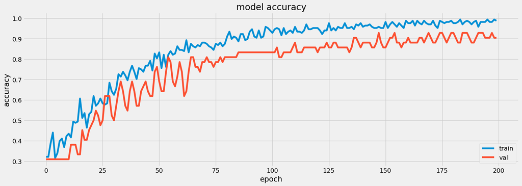

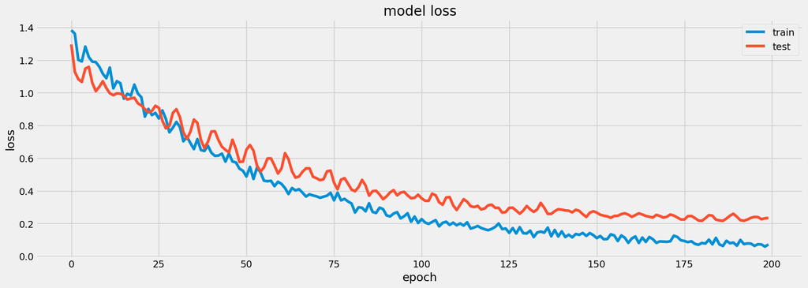

```python
import seaborn as sns
plt.style.use('fivethirtyeight')
rcParams['figure.figsize'] = 18, 6

plt.plot(history.history['accuracy'])
plt.plot(history.history['val_accuracy'])
plt.title('model accuracy')
plt.ylabel('accuracy')
plt.xlabel('epoch')
plt.legend(['train', 'val'], loc='lower right')
plt.show()

plt.plot(history.history['loss'])
plt.plot(history.history['val_loss'])
plt.title('model loss')
plt.ylabel('loss')
plt.xlabel('epoch')
plt.legend(['train', 'test'], loc='upper right')
plt.show()
```

Now we are going to predict the classes of the images in the dataset that we separated for testing.

```python
from sklearn.metrics import accuracy_score
from sklearn.metrics import classification_report
from sklearn.metrics import confusion_matrix
```

```python
predict = Model.predict(x_test)
```

```
3/3 ━━━━━━━━━━━━━━━━━━━━ 2s 399ms/step
```

```python
pred = np.argmax(predict, axis=1)
```

```python
true = np.argmax(y_test, axis=1)
```

We then calculate the overall accuracy of the test data:

```python
accuracy = accuracy_score(true,pred)
print(accuracy)
```

```
0.8888888888888888
```

We can also use the classification report to see some metrics by class:

```python
print(classification_report(true, pred))
```

```
              precision    recall  f1-score   support

           0       0.86      0.89      0.87        35
           1       1.00      0.96      0.98        28
           2       0.81      0.81      0.81        27

    accuracy                           0.89        90
   macro avg       0.89      0.89      0.89        90
weighted avg       0.89      0.89      0.89        90
```

```python
cm = confusion_matrix(true, pred)
print(cm)
```

```
[[31  0  4]
 [ 0 27  1]
 [ 5  0 22]]
```

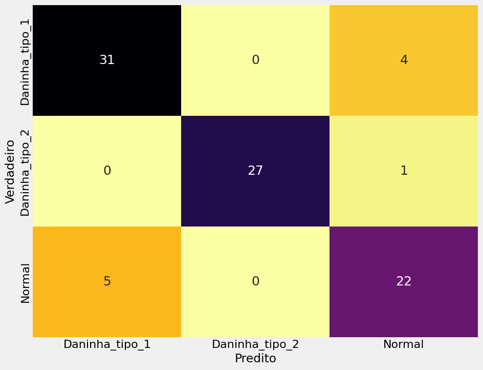

```python
class_list = ['Daninha_tipo_1', 'Daninha_tipo_2','Normal']
columns = class_list
r1 = pd.DataFrame(data=cm, columns=columns, index=columns)
fig, ax = plt.subplots(figsize=(10,8))
ax = sns.heatmap(r1, annot=True, annot_kws={"size": 18},fmt='d',cmap="inferno_r", cbar = False)
#for t in ax.texts: t.set_text(t.get_text() + " %")
ax.tick_params(labelsize=16)
ax.set_ylabel('Verdadeiro')
ax.set_xlabel('Predito')
```

Now let's divide the whole image into 128x128 patches and classify each of these parts of the image:

```python
path_img_to_pred = '/content/drive/MyDrive/Datasets/classificacao_cana_daninhas/AOI_img_rep.tif'
path_split = "/content/split_img"
if not os.path.isdir(path_split):
    os.mkdir(path_split)
```

```python
src = rasterio.open(path_img_to_pred)
out_meta = src.meta.copy()
qtd = 0
for n in range((src.meta['width']//128)):
  for m in range((src.meta['height']//128)):
    x = ((n*128))
    y = ((m*128))
    window = Window(x,y,128,128)
    win_transform = src.window_transform(window)
    arr_win = src.read(window=window)
    if arr_win.max() != 0:
      qtd = qtd + 1
      path_exp_img = os.path.join(path_split, 'img_' + str(qtd) + '.tif')
      out_meta.update({"driver": "GTiff","height": arr_win.shape[1],"width": arr_win.shape[2], "compress":'lzw', "transform":win_transform})
      with rasterio.open(path_exp_img, 'w', **out_meta) as dst:
          for i, layer in enumerate(arr_win, start=1):
              dst.write_band(i, layer.reshape(-1, layer.shape[-1]))
      print('Create img: ' + str(qtd))
    del arr_win
```

[output not shown]

[output cut: 4946 more lines]

[output not shown]

```python
n = [f for f in os.listdir(path_split)]
```

```python
df_full = pd.DataFrame([])
im_list = []
geom_list = []
for path_img in n:
  img = []
  path_full = os.path.join(path_split,path_img)
  ds = rasterio.open(path_full, 'r')
  im = ds.read()
  im = im.transpose([1,2,0])
  im = im[:,:,0:3]
  im = im/255
  im_list.append(im)
  geom = box(*ds.bounds)
  geom_list.append(geom)
```

```python
im_list = np.array(im_list)
```

```python
predict = Model.predict(im_list)
predict = np.argmax(predict, axis=1)
```

```
197/197 ━━━━━━━━━━━━━━━━━━━━ 1s 7ms/step
```

```python
df_full = gpd.GeoDataFrame({'classe':predict,"geometry":geom_list})
```

The generated result is a dataframe with polygons representing the areas of the image:

```python
df_full
```

|  | classe | geometry |
| --- | --- | --- |
| 0 | 2 | POLYGON ((803227.247 7689807.152, 803227.247 7... |
| 1 | 0 | POLYGON ((803386.417 7689915.670, 803386.417 7... |
| 2 | 2 | POLYGON ((803400.887 7689430.955, 803400.887 7... |
| 3 | 2 | POLYGON ((803437.061 7689655.226, 803437.061 7... |
| 4 | 2 | POLYGON ((803198.307 7690422.090, 803198.307 7... |
| ... | ... | ... |
| 6272 | 2 | POLYGON ((803487.706 7689568.411, 803487.706 7... |
| 6273 | 2 | POLYGON ((803343.007 7689322.436, 803343.007 7... |
| 6274 | 2 | POLYGON ((803321.302 7690262.929, 803321.302 7... |
| 6275 | 2 | POLYGON ((803400.887 7689590.115, 803400.887 7... |
| 6276 | 2 | POLYGON ((803393.652 7689445.424, 803393.652 7... |

6277 rows × 2 columns

```python
df_full = df_full.set_crs(src.crs.to_dict())
```

We plot this GeoDataFrame to see the result:

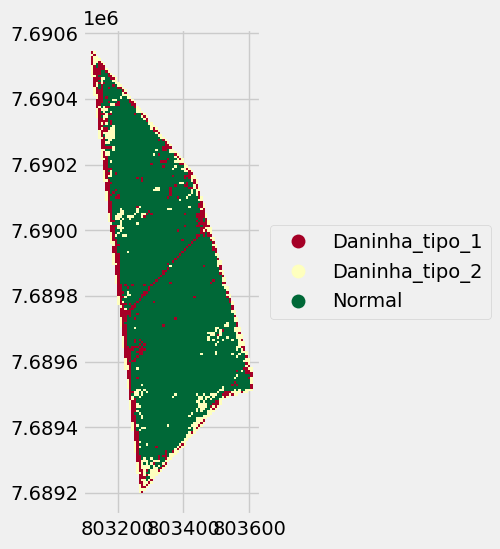

```python
ax = df_full.plot("classe",legend=True, cmap='RdYlGn',categorical=True, legend_kwds={"loc": "center left", "bbox_to_anchor": (1, 0.5)})

def replace_legend_items(legend, mapping):
    for txt in legend.texts:
        for k,v in mapping.items():
            if txt.get_text() == str(k):
                txt.set_text(v)

replace_legend_items(ax.get_legend(), dict_name)
```

```python
df_full.to_file('/content/veg_classification.shp')
```